## Estimate true prevalence from individuals samples using multiple tests – covariance scheme

### Description

Bayesian estimation of true prevalence from apparent prevalence obtained by applying *multiple* tests to *individual* samples. `truePrevMulti2` implements the approach described by Dendukuri and Joseph (2001), which uses a multinomial distribution to model observed test results, and in which conditional dependence between tests is modelled through covariances.

### Usage

```r
truePrevMulti2(x, n, prior, nchains = 2, burnin = 10000, update = 10000,
               verbose = FALSE)
```

### Arguments

| `x` | Vector of apparent test results; see details |
| --- | --- |
| `n` | The total sample size |
| `prior` | The prior distribution for `theta`; see details |
| `nchains` | The number of chains used in the estimation process; must be *≥2* |
| `burnin` | The number of discarded model iterations; defaults to 10,000 |
| `update` | The number of withheld model iterations; defaults to 10,000 |
| `verbose` | Logical flag, indicating if JAGS process output should be printed to the R console; defaults to `FALSE` |

### Details

`truePrevMulti2` calls on [**JAGS**](http://mcmc-jags.sourceforge.net/) via the [**rjags**](https://cran.r-project.org/package=rjags) package to estimate true prevalence from apparent prevalence in a Bayesian framework. `truePrevMulti2` fits a multinomial model to the apparent test results obtained by testing individual samples with a given number of tests. To see the actual fitted model, see the model slot of the `prev-class` object.

The vector of apparent tests results, `x`, must contain the number of samples corresponding to each combination of test results. To see how this vector is defined for the number of tests `h` at hand, use `define_x`.

Argument `prior` consists of prior distributions for:

- True Prevalence: `TP`
- SEnsitivity of each individual test: vector `SE`
- SPecificity of each individual test: vector `SP`
- Conditional covariance of all possible test combinations given a truly positive disease status: vector `a`
- Conditional covariance of all possible test combinations given a truly negative disease status: vector `b`

To see how `prior` is defined for the number of tests `n`, use `define_prior2`.

The values of `prior` can be specified in two ways, referred to as BUGS-style and list-style, respectively. See also below for some examples.

For BUGS-style specification, the values of `theta` should be given between curly brackets (i.e., `{}`), separated by line breaks. `theta` values can be specified to be deterministic (i.e., fixed), using the `<-` operator, or stochastic, using the `~` operator.

Alternatively, priors can be specified in a *named* `list()`.

More info on specifying distributions is available here.

### Value

A `prev-class` object.

### Note

Markov chain Monte Carlo sampling in `truePrevMulti2` is performed by [**JAGS**](http://mcmc-jags.sourceforge.net/) (Just Another Gibbs Sampler) through the [**rjags**](https://cran.r-project.org/package=rjags) package. JAGS can be downloaded from http://sourceforge.net/projects/mcmc-jags/.

### References

- Dendukuri N, Joseph L (2001) Bayesian approaches to modeling the conditional dependence between multiple diagnostic tests. *Biometrics* **57**:158-167. http://dx.doi.org/10.1111/j.0006-341X.2001.00158.x

### See Also

`define_x`: how to define the vector of apparent test results `x`

`define_prior2`: how to define `prior`

[**coda**](https://cran.r-project.org/package=coda) for various functions that can be applied to the `prev@mcmc` object

`truePrevMulti`: estimate true prevalence from apparent prevalence obtained by testing *individual* samples with multiple tests, using a conditional probability scheme

`truePrev`: estimate true prevalence from apparent prevalence obtained by testing *individual* samples with a single test

`truePrevPools`: estimate true prevalence from apparent prevalence obtained by testing *pooled* samples with a single test

`betaPERT`: calculate the parameters of a Beta-PERT distribution

`betaExpert`: calculate the parameters of a Beta distribution based on expert opinion

### Examples

```r
## ===================================================== ##
## 2-TEST EXAMPLE: Strongyloides                         ##
## ----------------------------------------------------- ##
## Two tests were performed on 162 humans                ##
## -> T1 = stool examination                             ##
## -> T2 = serology test                                 ##
## Expert opinion generated the following priors:        ##
## -> SE1 ~ dbeta( 4.44, 13.31)                          ##
## -> SP1 ~ dbeta(71.25,  3.75)                          ##
## -> SE2 ~ dbeta(21.96,  5.49)                          ##
## -> SP2 ~ dbeta( 4.10,  1.76)                          ##
## The following results were obtained:                  ##
## -> 38 samples T1+,T2+                                 ##
## ->  2 samples T1+,T2-                                 ##
## -> 87 samples T1-,T2+                                 ##
## -> 35 samples T1-,T2-                                 ##
## ===================================================== ##

## how is the 2-test model defined?
define_x(2)
```

```
#> Definition of the apparent test results, 'x', for 2 tests:
#> x[1] : T1+,T2+
#> x[2] : T1+,T2-
#> x[3] : T1-,T2+
#> x[4] : T1-,T2-
```

```r
define_prior2(2)
```

```
#> Covariance scheme
#> Definition of the prior for 2 tests:
#> TP :    True Prevalence
#> SE[1] : Sensitity T1
#> SE[2] : Sensitity T2
#> SP[1] : Specificity T1
#> SP[2] : Specificity T2
#> a[1] :  Covariance(T1,T2|D+)
#> b[1] :  Covariance(T1,T2|D-)
```

```r
## fit Strongyloides 2-test model
## a first model assumes conditional independence
## -> set covariance terms to zero
strongy_indep <-
truePrevMulti2(
  x = c(38, 2, 87, 35),
  n = 162,
  prior = {
    TP ~ dbeta(1, 1)
    SE[1] ~ dbeta( 4.44, 13.31)
    SP[1] ~ dbeta(71.25,  3.75)
    SE[2] ~ dbeta(21.96,  5.49)
    SP[2] ~ dbeta( 4.10,  1.76)
    a[1] <- 0
    b[1] <- 0
  })

## show model results
strongy_indep
```

```
#>        mean median  mode    sd  2.5% 97.5%
#> TP    0.736  0.752 0.774 0.086 0.526 0.865
#> SE[1] 0.324  0.317 0.313 0.047 0.251 0.437
#> SE[2] 0.914  0.917 0.927 0.030 0.845 0.964
#> SP[1] 0.963  0.966 0.971 0.018 0.921 0.990
#> SP[2] 0.703  0.712 0.744 0.152 0.405 0.957
#> a[1]  0.000  0.000 0.000 0.000 0.000 0.000
#> b[1]  0.000  0.000 0.000 0.000 0.000 0.000
#>
#> Multivariate BGR statistic = 1.0005
#> BGR values substantially above 1 indicate lack of convergence
```

```r
## fit same model using 'list-style'
strongy_indep <-
truePrevMulti2(
  x = c(38, 2, 87, 35),
  n = 162,
  prior =
    list(
      TP = list(dist = "beta", alpha = 1, beta = 1),
      SE1 = list(dist = "beta", alpha = 4.44, beta = 13.31),
      SP1 = list(dist = "beta", alpha = 71.25, beta = 3.75),
      SE2 = list(dist = "beta", alpha = 21.96, beta = 5.49),
      SP2 = list(dist = "beta", alpha = 4.10, beta = 1.76),
      a1 = 0,
      b1 = 0
    )
  )

## show model results
strongy_indep
```

```
#>        mean median  mode    sd  2.5% 97.5%
#> TP    0.740  0.755 0.777 0.084 0.533 0.864
#> SE[1] 0.322  0.316 0.310 0.045 0.252 0.427
#> SE[2] 0.914  0.917 0.916 0.030 0.847 0.964
#> SP[1] 0.963  0.966 0.972 0.018 0.921 0.990
#> SP[2] 0.710  0.720 0.745 0.150 0.408 0.959
#> a[1]  0.000  0.000 0.000 0.000 0.000 0.000
#> b[1]  0.000  0.000 0.000 0.000 0.000 0.000
#>
#> Multivariate BGR statistic = 1.0024
#> BGR values substantially above 1 indicate lack of convergence
```

```r
## fit Strongyloides 2-test model
## a second model allows for conditional dependence
## -> a[1] is the covariance between T1 and T2, given D+
## -> b[1] is the covariance between T1 and T2, given D-
## -> a[1] and b[1] can range between +/- 2^-h, ie, (-.25, .25)
strongy <-
truePrevMulti2(
  x = c(38, 2, 87, 35),
  n = 162,
  prior = {
    TP ~ dbeta(1, 1)
    SE[1] ~ dbeta( 4.44, 13.31)
    SP[1] ~ dbeta(71.25,  3.75)
    SE[2] ~ dbeta(21.96,  5.49)
    SP[2] ~ dbeta( 4.10,  1.76)
    a[1] ~ dunif(-0.25, 0.25)
    b[1] ~ dunif(-0.25, 0.25)
  })

## explore model structure
str(strongy)         # overall structure
```

```
#> Formal class 'prev' [package "prevalence"] with 4 slots
#>   ..@ par        :List of 7
#>   .. ..$ x      : num [1:4] 38 2 87 35
#>   .. ..$ n      : num 162
#>   .. ..$ prior  :List of 7
#>   .. .. ..$ :List of 2
#>   .. .. .. ..$ : chr "TP"
#>   .. .. .. ..$ :List of 2
#>   .. .. .. .. ..$ d: chr "beta"
#>   .. .. .. .. ..$ p: num [1:2] 1 1
#>   .. .. ..$ :List of 2
#>   .. .. .. ..$ : chr "SE[1]"
#>   .. .. .. ..$ :List of 2
#>   .. .. .. .. ..$ d: chr "beta"
#>   .. .. .. .. ..$ p: num [1:2] 4.44 13.31
#>   .. .. ..$ :List of 2
#>   .. .. .. ..$ : chr "SE[2]"
#>   .. .. .. ..$ :List of 2
#>   .. .. .. .. ..$ d: chr "beta"
#>   .. .. .. .. ..$ p: num [1:2] 21.96 5.49
#>   .. .. ..$ :List of 2
#>   .. .. .. ..$ : chr "SP[1]"
#>   .. .. .. ..$ :List of 2
#>   .. .. .. .. ..$ d: chr "beta"
#>   .. .. .. .. ..$ p: num [1:2] 71.25 3.75
#>   .. .. ..$ :List of 2
#>   .. .. .. ..$ : chr "SP[2]"
#>   .. .. .. ..$ :List of 2
#>   .. .. .. .. ..$ d: chr "beta"
#>   .. .. .. .. ..$ p: num [1:2] 4.1 1.76
#>   .. .. ..$ :List of 2
#>   .. .. .. ..$ : chr "a[1]"
#>   .. .. .. ..$ :List of 2
#>   .. .. .. .. ..$ d: chr "uniform"
#>   .. .. .. .. ..$ p: num [1:2] -0.25 0.25
#>   .. .. ..$ :List of 2
#>   .. .. .. ..$ : chr "b[1]"
#>   .. .. .. ..$ :List of 2
#>   .. .. .. .. ..$ d: chr "uniform"
#>   .. .. .. .. ..$ p: num [1:2] -0.25 0.25
```

[output cut: 55 more lines]

```
#>   .. ..$ DIC   :List of 3
#>   .. .. ..$ deviance:Class 'mcarray'  Named num [1:26] 14.4 14.4 0 0 0 ...
#>   .. .. .. .. ..- attr(*, "names")= chr [1:26] "x" "x2" "O6[1]" "O5[1]" ...
#>   .. .. ..$ penalty :Class 'mcarray'  Named num [1:26] 64749 64749 0 0 0 ...
#>   .. .. .. .. ..- attr(*, "names")= chr [1:26] "x" "x2" "O6[1]" "O5[1]" ...
#>   .. .. ..$ type    : chr "pD"
#>   .. .. ..- attr(*, "class")= chr "dic"
#>   .. ..$ BGR   :List of 2
#>   .. .. ..$ psrf : num [1:7, 1:2] 1 1 1 1 1 ...
#>   .. .. .. ..- attr(*, "dimnames")=List of 2
#>   .. .. .. .. ..$ : chr [1:7] "SE[1]" "SE[2]" "SP[1]" "SP[2]" ...
#>   .. .. .. .. ..$ : chr [1:2] "Point est." "Upper C.I."
#>   .. .. ..$ mpsrf: num 1
#>   .. .. ..- attr(*, "class")= chr "gelman.diag"
#>   .. ..$ bayesP: num 1
```

```r
str(strongy@par)     # structure of slot 'par'
```

```
#> List of 7
#>  $ x      : num [1:4] 38 2 87 35
#>  $ n      : num 162
#>  $ prior  :List of 7
#>   ..$ :List of 2
#>   .. ..$ : chr "TP"
#>   .. ..$ :List of 2
#>   .. .. ..$ d: chr "beta"
#>   .. .. ..$ p: num [1:2] 1 1
#>   ..$ :List of 2
#>   .. ..$ : chr "SE[1]"
#>   .. ..$ :List of 2
#>   .. .. ..$ d: chr "beta"
#>   .. .. ..$ p: num [1:2] 4.44 13.31
#>   ..$ :List of 2
#>   .. ..$ : chr "SE[2]"
#>   .. ..$ :List of 2
#>   .. .. ..$ d: chr "beta"
#>   .. .. ..$ p: num [1:2] 21.96 5.49
#>   ..$ :List of 2
#>   .. ..$ : chr "SP[1]"
#>   .. ..$ :List of 2
#>   .. .. ..$ d: chr "beta"
#>   .. .. ..$ p: num [1:2] 71.25 3.75
#>   ..$ :List of 2
#>   .. ..$ : chr "SP[2]"
#>   .. ..$ :List of 2
#>   .. .. ..$ d: chr "beta"
#>   .. .. ..$ p: num [1:2] 4.1 1.76
#>   ..$ :List of 2
#>   .. ..$ : chr "a[1]"
#>   .. ..$ :List of 2
#>   .. .. ..$ d: chr "uniform"
#>   .. .. ..$ p: num [1:2] -0.25 0.25
#>   ..$ :List of 2
#>   .. ..$ : chr "b[1]"
#>   .. ..$ :List of 2
#>   .. .. ..$ d: chr "uniform"
#>   .. .. ..$ p: num [1:2] -0.25 0.25
#>  $ nchains: num 2
#>  $ burnin : num 10000
#>  $ update : num 10000
#>  $ inits  : NULL
```

```r
str(strongy@mcmc)    # structure of slot 'mcmc'
```

```
#> List of 8
#>  $ TP    :List of 2
#>   ..$ :Class 'mcmc'  atomic [1:10000] 0.606 0.577 0.573 0.494 0.638 ...
#>   .. .. ..- attr(*, "mcpar")= num [1:3] 11001 21000 1
#>   ..$ :Class 'mcmc'  atomic [1:10000] 0.791 0.832 0.862 0.813 0.829 ...
#>   .. .. ..- attr(*, "mcpar")= num [1:3] 11001 21000 1
#>   ..- attr(*, "class")= chr "mcmc.list"
#>  $ SE[1] :List of 2
#>   ..$ :Class 'mcmc'  atomic [1:10000] 0.387 0.37 0.354 0.383 0.378 ...
#>   .. .. ..- attr(*, "mcpar")= num [1:3] 11001 21000 1
#>   ..$ :Class 'mcmc'  atomic [1:10000] 0.263 0.268 0.29 0.303 0.271 ...
#>   .. .. ..- attr(*, "mcpar")= num [1:3] 11001 21000 1
#>   ..- attr(*, "class")= chr "mcmc.list"
#>  $ SE[2] :List of 2
#>   ..$ :Class 'mcmc'  atomic [1:10000] 0.834 0.836 0.848 0.874 0.856 ...
#>   .. .. ..- attr(*, "mcpar")= num [1:3] 11001 21000 1
#>   ..$ :Class 'mcmc'  atomic [1:10000] 0.864 0.866 0.872 0.87 0.843 ...
#>   .. .. ..- attr(*, "mcpar")= num [1:3] 11001 21000 1
#>   ..- attr(*, "class")= chr "mcmc.list"
#>  $ SP[1] :List of 2
#>   ..$ :Class 'mcmc'  atomic [1:10000] 0.908 0.912 0.916 0.932 0.925 ...
#>   .. .. ..- attr(*, "mcpar")= num [1:3] 11001 21000 1
#>   ..$ :Class 'mcmc'  atomic [1:10000] 0.906 0.897 0.912 0.936 0.921 ...
#>   .. .. ..- attr(*, "mcpar")= num [1:3] 11001 21000 1
#>   ..- attr(*, "class")= chr "mcmc.list"
#>  $ SP[2] :List of 2
#>   ..$ :Class 'mcmc'  atomic [1:10000] 0.431 0.421 0.413 0.401 0.44 ...
#>   .. .. ..- attr(*, "mcpar")= num [1:3] 11001 21000 1
#>   ..$ :Class 'mcmc'  atomic [1:10000] 0.75 0.655 0.645 0.601 0.712 ...
#>   .. .. ..- attr(*, "mcpar")= num [1:3] 11001 21000 1
#>   ..- attr(*, "class")= chr "mcmc.list"
#>  $ a[1]  :List of 2
#>   ..$ :Class 'mcmc'  atomic [1:10000] 0.0403 0.0367 0.0301 0.0307 0.0315 ...
#>   .. .. ..- attr(*, "mcpar")= num [1:3] 11001 21000 1
#>   ..$ :Class 'mcmc'  atomic [1:10000] 0.0352 0.0318 0.0278 0.0307 0.0337 ...
#>   .. .. ..- attr(*, "mcpar")= num [1:3] 11001 21000 1
#>   ..- attr(*, "class")= chr "mcmc.list"
#>  $ b[1]  :List of 2
#>   ..$ :Class 'mcmc'  atomic [1:10000] 0.02334 0.03267 0.01449 0.00939 0.01021 ...
#>   .. .. ..- attr(*, "mcpar")= num [1:3] 11001 21000 1
#>   ..$ :Class 'mcmc'  atomic [1:10000] 0.0044 -0.0304 -0.0144 -0.011 0.0223 ...
#>   .. .. ..- attr(*, "mcpar")= num [1:3] 11001 21000 1
#>   ..- attr(*, "class")= chr "mcmc.list"
#>  $ bayesP:List of 2
#>   ..$ :Class 'mcmc'  atomic [1:10000] 1 1 1 1 1 1 1 1 1 1 ...
#>   .. .. ..- attr(*, "mcpar")= num [1:3] 11001 21000 1
#>   ..$ :Class 'mcmc'  atomic [1:10000] 1 1 1 1 1 1 1 1 1 1 ...
#>   .. .. ..- attr(*, "mcpar")= num [1:3] 11001 21000 1
#>   ..- attr(*, "class")= chr "mcmc.list"
```

```r
strongy@model        # fitted model
```

```
#> model {
#>   x[1:4] ~ dmulti(AP[1:4], n)
#>
#>   prob_se[1] <- SE[1] * SE[2] + a[1]
#>   prob_se[2] <- SE[1] * (1 - SE[2]) - a[1]
#>   prob_se[3] <- (1 - SE[1]) * SE[2] - a[1]
#>   prob_se[4] <- (1 - SE[1]) * (1 - SE[2]) + a[1]
#>
#>   prob_sp[4] <- SP[1] * SP[2] + b[1]
#>   prob_sp[3] <- SP[1] * (1 - SP[2]) - b[1]
#>   prob_sp[2] <- (1 - SP[1]) * SP[2] - b[1]
#>   prob_sp[1] <- (1 - SP[1]) * (1 - SP[2]) + b[1]
#>
#>   for (i in 1:4) {
#>     AP[i] <- TP * prob_se[i] + (1 - TP) * prob_sp[i]
#>
#>     constraint1[i] <- step(AP[i])
#>     O1[i] ~ dbern(constraint1[i])
#>     constraint2[i] <- step(AP[i] - 1)
#>     O2[i] ~ dbern(constraint2[i])
#>     constraint3[i] <- step(prob_se[i])
#>     O3[i] ~ dbern(constraint3[i])
#>     constraint4[i] <- step(prob_se[i] - 1)
#>     O4[i] ~ dbern(constraint4[i])
#>     constraint5[i] <- step(prob_sp[i])
#>     O5[i] ~ dbern(constraint5[i])
#>     constraint6[i] <- step(prob_sp[i] - 1)
#>     O6[i] ~ dbern(constraint6[i])
#>   }
#>
#>   TP ~ dbeta(1, 1)
#>   SE[1] ~ dbeta(4.44, 13.31)
#>   SE[2] ~ dbeta(21.96, 5.49)
#>   SP[1] ~ dbeta(71.25, 3.75)
#>   SP[2] ~ dbeta(4.1, 1.76)
#>   a[1] ~ dunif(-0.25, 0.25)
#>   b[1] ~ dunif(-0.25, 0.25)
#>
#>   x2[1:4] ~ dmulti(AP[1:4], n)
#>   for (i in 1:4) {
#>     d1[i] <- x[i] * log(max(x[i],1) / (AP[i]*n))
#>     d2[i] <- x2[i] * log(max(x2[i],1) / (AP[i]*n))
#>   }
#>   G0 <- sum(d1[])
#>   Gt <- sum(d2[])
#>   bayesP <- step(G0 - Gt)
#> }
```

```r
strongy@diagnostics  # DIC, BGR and Bayes-P values
```

```
#> $DIC
#> Mean deviance:  28.75
#> penalty 129498
#> Penalized deviance: 129527
#>
#> $BGR
#> Potential scale reduction factors:
#>
#>       Point est. Upper C.I.
#> SE[1]          1       1.01
#> SE[2]          1       1.00
#> SP[1]          1       1.00
#> SP[2]          1       1.01
#> TP             1       1.00
#> a              1       1.01
#> b              1       1.01
#>
#> Multivariate psrf
#>
#> 1
#>
#> $bayesP
#> [1] 1
```

```r
## standard methods
print(strongy)
```

```
#>        mean median  mode    sd   2.5% 97.5%
#> TP    0.842  0.861 0.889 0.109  0.577 0.991
#> SE[1] 0.284  0.278 0.270 0.042  0.219 0.387
#> SE[2] 0.831  0.828 0.821 0.046  0.750 0.923
#> SP[1] 0.938  0.942 0.949 0.027  0.876 0.980
#> SP[2] 0.636  0.648 0.666 0.186  0.278 0.937
#> a[1]  0.033  0.034 0.037 0.014  0.005 0.059
#> b[1]  0.011  0.009 0.003 0.022 -0.028 0.061
#>
#> Multivariate BGR statistic = 1.0028
#> BGR values substantially above 1 indicate lack of convergence
```

```r
summary(strongy)
```

```
#> $TP
#>                 mean    median      mode        sd        var      2.5%
#> chain 1    0.8436507 0.8610896 0.8909832 0.1056432 0.01116048 0.5935869
#> chain 2    0.8399529 0.8601476 0.8884333 0.1118842 0.01251807 0.5600494
#> all chains 0.8418018 0.8606750 0.8892378 0.1088214 0.01184210 0.5771182
#>                97.5% samples
#> chain 1    0.9910774   10000
#> chain 2    0.9907360   10000
#> all chains 0.9909564   20000
#>
#> $`SE[1]`
#>                 mean    median      mode         sd         var      2.5%
#> chain 1    0.2832589 0.2778963 0.2678959 0.04053746 0.001643286 0.2185224
#> chain 2    0.2856656 0.2788679 0.2719301 0.04395325 0.001931888 0.2201134
#> all chains 0.2844622 0.2784071 0.2695707 0.04229593 0.001788946 0.2190952
#>                97.5% samples
#> chain 1    0.3793029   10000
#> chain 2    0.3942700   10000
#> all chains 0.3871296   20000
#>
#> $`SE[2]`
#>                 mean    median      mode         sd         var      2.5%
#> chain 1    0.8318448 0.8290919 0.8248206 0.04586113 0.002103243 0.7505227
#> chain 2    0.8298677 0.8267019 0.8155388 0.04566812 0.002085577 0.7488405
#> all chains 0.8308563 0.8279175 0.8211626 0.04577426 0.002095283 0.7496565
#>                97.5% samples
#> chain 1    0.9242968   10000
#> chain 2    0.9207437   10000
#> all chains 0.9228179   20000
#>
#> $`SP[1]`
#>                 mean    median      mode         sd          var      2.5%
#> chain 1    0.9380062 0.9418135 0.9493370 0.02654011 0.0007043775 0.8769372
#> chain 2    0.9386962 0.9428199 0.9500813 0.02744737 0.0007533582 0.8745201
#> all chains 0.9383512 0.9423324 0.9493613 0.02699908 0.0007289504 0.8758966
#>                97.5% samples
#> chain 1    0.9787722   10000
#> chain 2    0.9802919   10000
#> all chains 0.9796821   20000
#>
```

[output cut: 14 more lines]

```
#> all chains 0.03324563 0.03383647 0.03707119 0.01381983 0.0001909878
#>                   2.5%      97.5% samples
#> chain 1    0.004390537 0.05811966   10000
#> chain 2    0.004786837 0.06002443   10000
#> all chains 0.004588747 0.05927007   20000
#>
#> $`b[1]`
#>                  mean      median        mode         sd          var
#> chain 1    0.01183860 0.009658547 0.004278029 0.02248901 0.0005057554
#> chain 2    0.01040055 0.008599015 0.002992741 0.02175976 0.0004734874
#> all chains 0.01111957 0.009129480 0.002841077 0.02213852 0.0004901139
#>                   2.5%      97.5% samples
#> chain 1    -0.02838421 0.06168614   10000
#> chain 2    -0.02858627 0.05925678   10000
#> all chains -0.02839380 0.06059105   20000
```

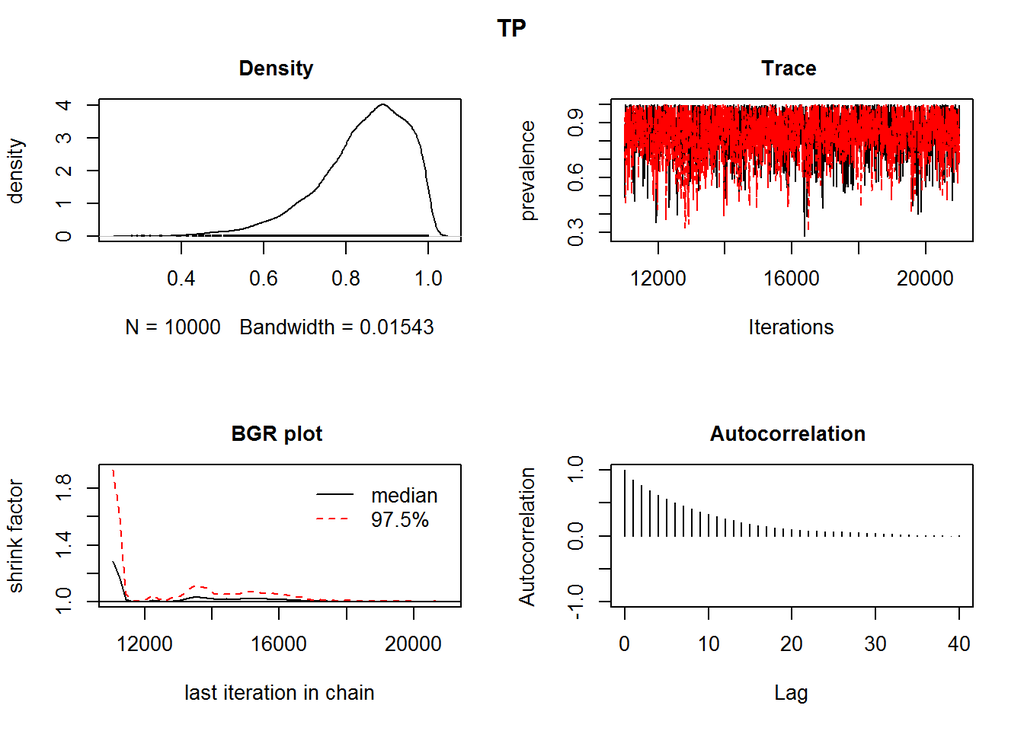

```r
par(mfrow = c(2, 2))
plot(strongy)           # shows plots of TP by default
```

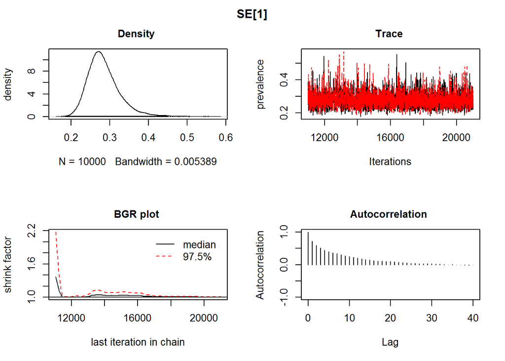

```r
plot(strongy, "SE[1]")  # same plots for SE1
```

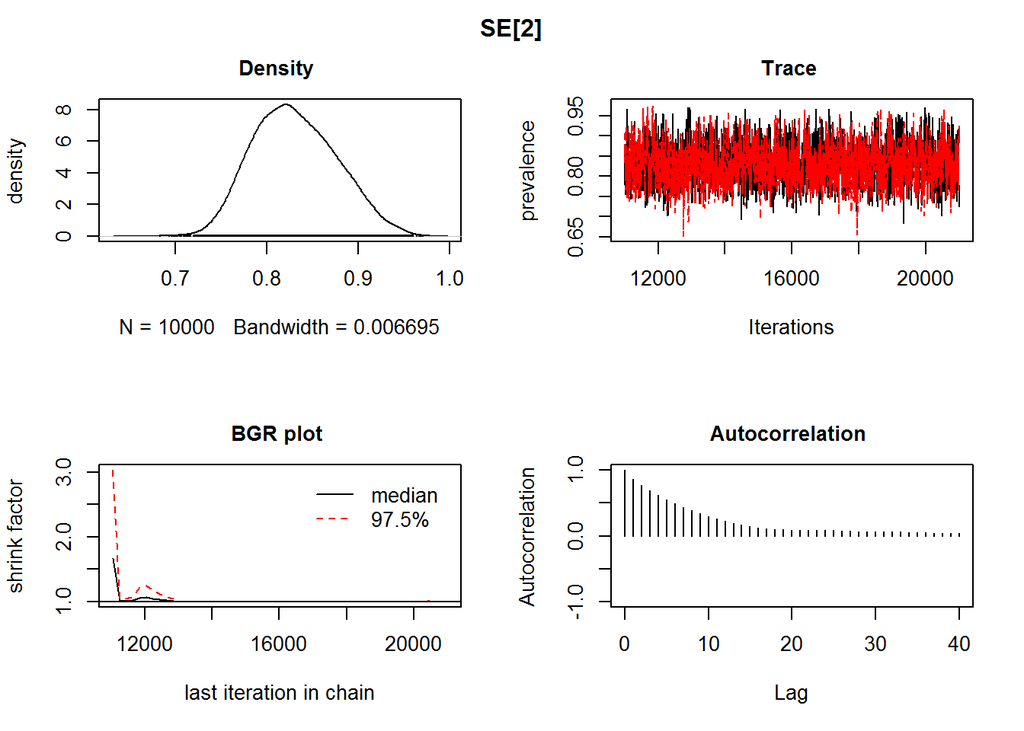

```r
plot(strongy, "SE[2]")  # same plots for SE2
```

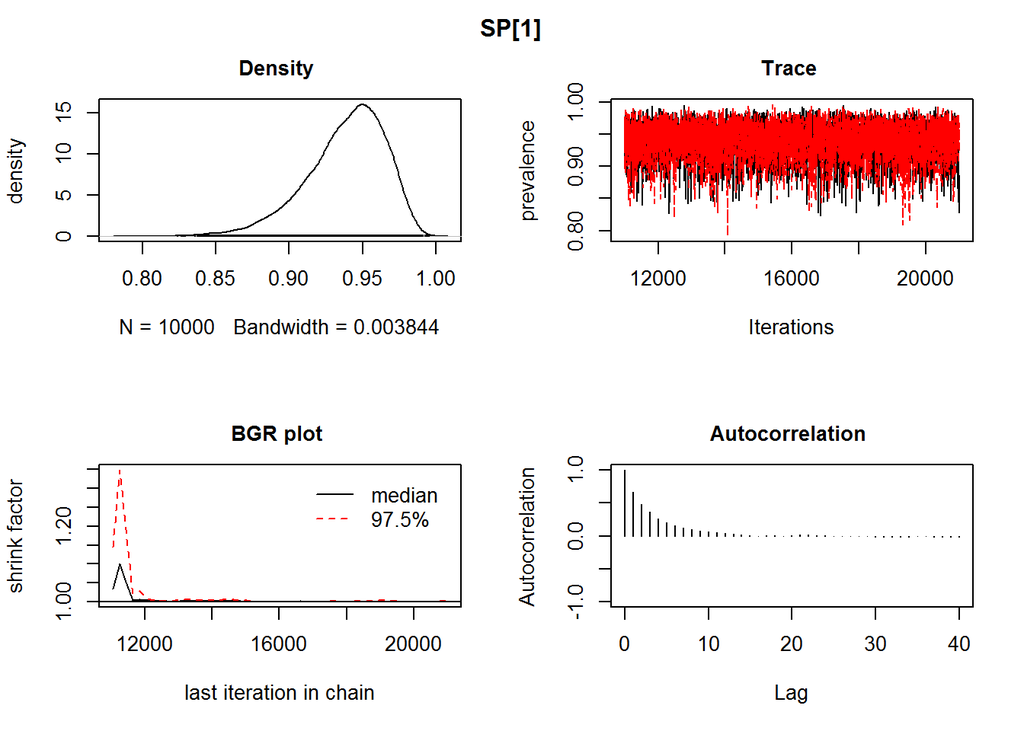

```r
plot(strongy, "SP[1]")  # same plots for SP1
```

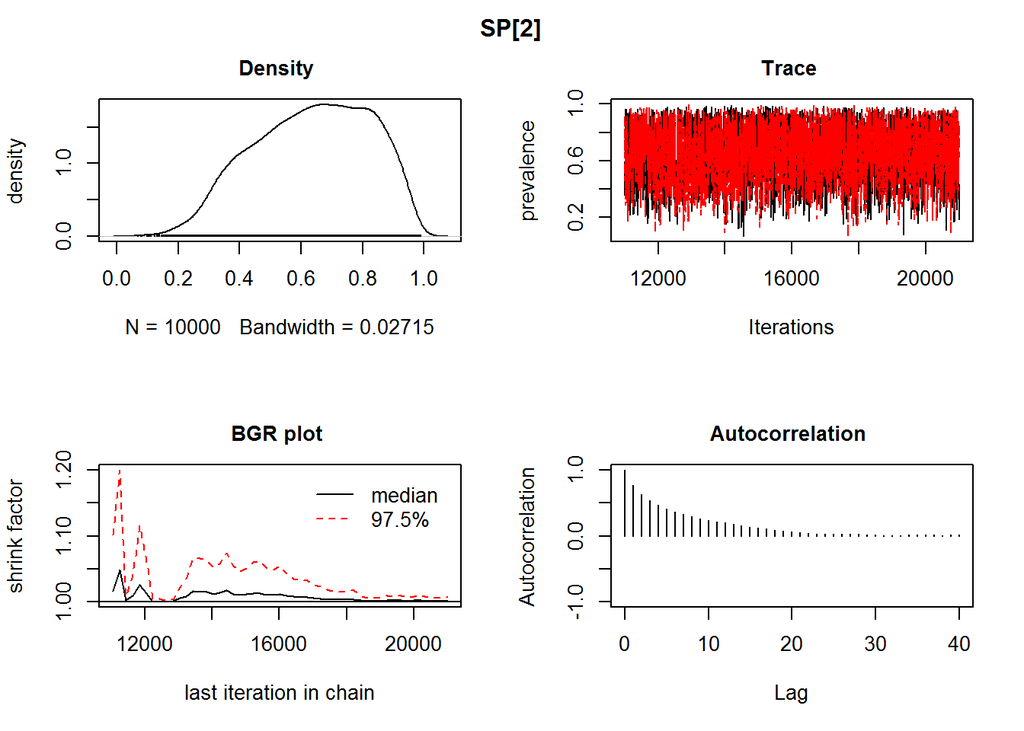

```r
plot(strongy, "SP[2]")  # same plots for SP2
```

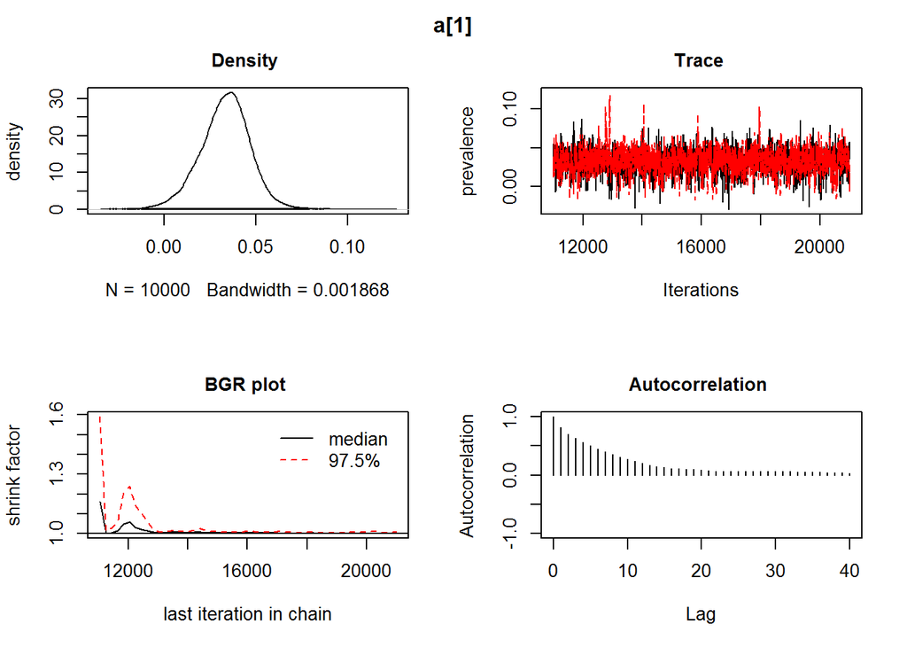

```r
plot(strongy, "a[1]")   # same plots for a[1]
```

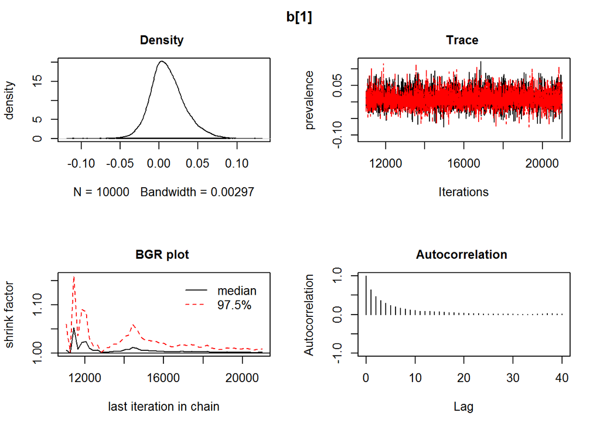

```r
plot(strongy, "b[1]")   # same plots for b[1]
```

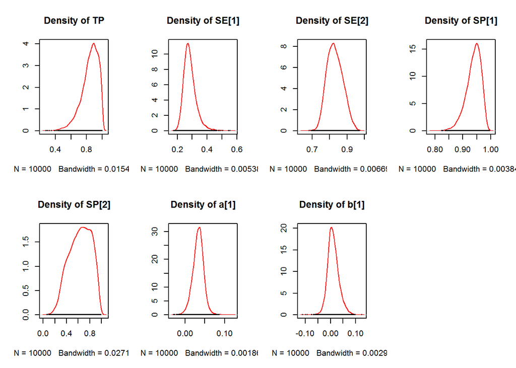

```r
## coda plots of all parameters
par(mfrow = c(2, 4)); densplot(strongy, col = "red")
par(mfrow = c(2, 4)); traceplot(strongy)
```

[figure not shown]

```r
par(mfrow = c(2, 4)); gelman.plot(strongy)
```

[figure not shown]

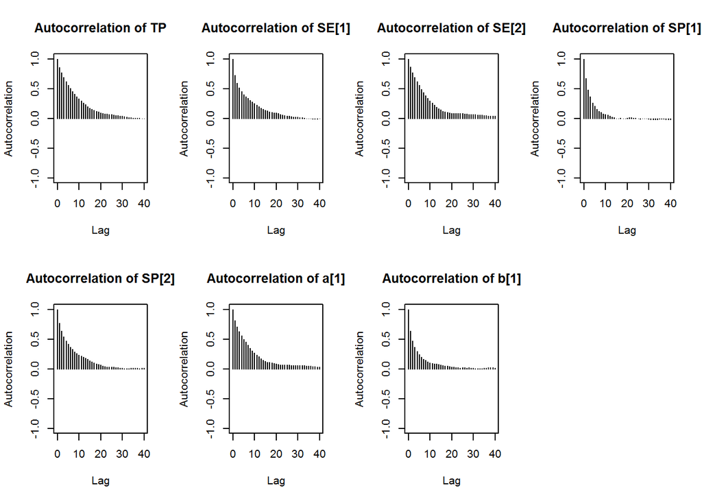

```r
par(mfrow = c(2, 4)); autocorr.plot(strongy)
```

Page last modified: Mon, 08 Feb 2016. [View Rmarkdown source code on GitHub](https://github.com/brechtdv/prevalence-www).